# Capstone Project: Loan Default Prediction

## MIT Professional Education

##### Author: Charlotte Bredy-Maux

##### Created on: February, 3rd 2024

##### Last Modified on: February, 3rd 2024

### Problem Statement Key-Points

A bank's consumer credit department wants to update its decision-making process for credit scoring through Machine Learning and Deep Learning methods. Model's biases is a major consideration and the Equal Credit Opportunity must be respected. Specifically, the model is based on intrisically biased data.

Additionaly, recommendations and features importance must be provided for both for approved loans and rejected loans.

**The goals are to:**

1. Perform customer analysis i.e., EDA
2. Build an ML model that predicts the probability for a given customer to be granted a loan
3. Interpretability and feature importances for both classes

## I. Data Loading

- Download the *hmeq.csv* database and load it into a DataFrame (pandas), marked *df* (pandas).
- Display the database attributes and their number. What type are they (real, nominal or binary variables...)
- Data Pre-Processing:
  - replace missing values with mode using *df.fillna*.
  - identify sensitive variables to eventually protect
  - identify over-representation or under-representation of categories
  - transform non-numeric variables into binary variables using *pandas.get_dummies* when applicable.
  - remove duplicates 'O.O'
- Create a learning database and a test database (70\% learning 30\% test)

### Download the packages and the hmeq.csv database and load it into a DataFrame (pandas), marked df (pandas).

```python
import pandas as pd
import numpy as np
import seaborn as sns
import matplotlib.pyplot as plt

df_1 = pd.read_csv('hmeq.csv')
df = df_1.copy()
df=pd.DataFrame(df)
df
```

|  | BAD | LOAN | MORTDUE | VALUE | REASON | JOB | YOJ | DEROG | DELINQ | CLAGE | NINQ | CLNO | DEBTINC |
| --- | --- | --- | --- | --- | --- | --- | --- | --- | --- | --- | --- | --- | --- |
| 0 | 1 | 1100 | 25860.0 | 39025.0 | HomeImp | Other | 10.5 | 0.0 | 0.0 | 94.366667 | 1.0 | 9.0 | NaN |
| 1 | 1 | 1300 | 70053.0 | 68400.0 | HomeImp | Other | 7.0 | 0.0 | 2.0 | 121.833333 | 0.0 | 14.0 | NaN |
| 2 | 1 | 1500 | 13500.0 | 16700.0 | HomeImp | Other | 4.0 | 0.0 | 0.0 | 149.466667 | 1.0 | 10.0 | NaN |
| 3 | 1 | 1500 | NaN | NaN | NaN | NaN | NaN | NaN | NaN | NaN | NaN | NaN | NaN |
| 4 | 0 | 1700 | 97800.0 | 112000.0 | HomeImp | Office | 3.0 | 0.0 | 0.0 | 93.333333 | 0.0 | 14.0 | NaN |
| ... | ... | ... | ... | ... | ... | ... | ... | ... | ... | ... | ... | ... | ... |
| 5955 | 0 | 88900 | 57264.0 | 90185.0 | DebtCon | Other | 16.0 | 0.0 | 0.0 | 221.808718 | 0.0 | 16.0 | 36.112347 |
| 5956 | 0 | 89000 | 54576.0 | 92937.0 | DebtCon | Other | 16.0 | 0.0 | 0.0 | 208.692070 | 0.0 | 15.0 | 35.859971 |
| 5957 | 0 | 89200 | 54045.0 | 92924.0 | DebtCon | Other | 15.0 | 0.0 | 0.0 | 212.279697 | 0.0 | 15.0 | 35.556590 |
| 5958 | 0 | 89800 | 50370.0 | 91861.0 | DebtCon | Other | 14.0 | 0.0 | 0.0 | 213.892709 | 0.0 | 16.0 | 34.340882 |
| 5959 | 0 | 89900 | 48811.0 | 88934.0 | DebtCon | Other | 15.0 | 0.0 | 0.0 | 219.601002 | 0.0 | 16.0 | 34.571519 |

5960 rows × 13 columns

The database has 13 variables and 5960 observations.

### Display the database attributes and their number. What type are they (real, nominal or binary variables...)? How many classes are there ?

```python
atbs=df.columns #Display attributes, their numbers and types.
nb_atbs=len(atbs)
print(atbs,nb_atbs)
print("There are",nb_atbs,"attributes")
```

```
Index(['BAD', 'LOAN', 'MORTDUE', 'VALUE', 'REASON', 'JOB', 'YOJ', 'DEROG',
       'DELINQ', 'CLAGE', 'NINQ', 'CLNO', 'DEBTINC'],
      dtype='object') 13
There are 13 attributes
```

```python
df.dtypes #Display attributes types
```

```
BAD          int64
LOAN         int64
MORTDUE    float64
VALUE      float64
REASON      object
JOB         object
YOJ        float64
DEROG      float64
DELINQ     float64
CLAGE      float64
NINQ       float64
CLNO       float64
DEBTINC    float64
dtype: object
```

```python
cl=df.select_dtypes(include=['object'])  #Display the number of classes
nb_cl=len(cl.columns)
print("There are",nb_cl,"classes")
```

```
There are 2 classes
```

### Data Cleaning and Pre-Processing :

#### replace missing values with mode using df.fillna

#### transform non-numeric variables into binary variables using pandas.get_dummies

```python
 # Display unique values and their counts for categorical columns
categorical_columns = ['JOB', 'REASON']

for column in categorical_columns:
    print(f"Frequency distribution for {column}:")
    print(df[column].value_counts())
    print("\n")
```

```
Frequency distribution for JOB:
Other      2388
ProfExe    1276
Office      948
Mgr         767
Self        193
Sales       109
Name: JOB, dtype: int64


Frequency distribution for REASON:
DebtCon    3928
HomeImp    1780
Name: REASON, dtype: int64
```

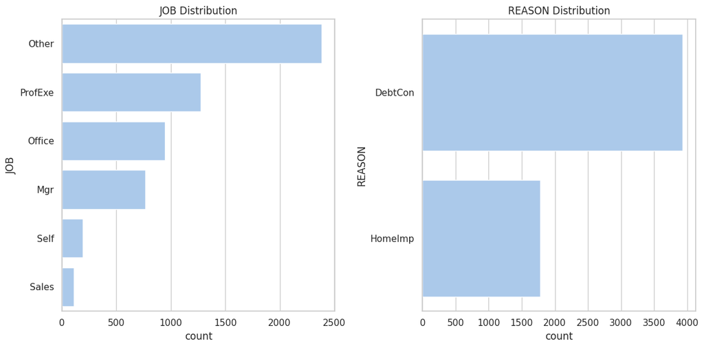

```python
# Set up the matplotlib figure
plt.figure(figsize=(12, 6))
sns.set_theme(style="whitegrid", palette="pastel")

# Loop through each categorical column and plot a bar chart
for i, column in enumerate(categorical_columns, 1):
    plt.subplot(1, len(categorical_columns), i)
    sns.countplot(data=df, y=column, order=df[column].value_counts().index)
    plt.title(f'{column} Distribution')

plt.tight_layout()
plt.show()
```

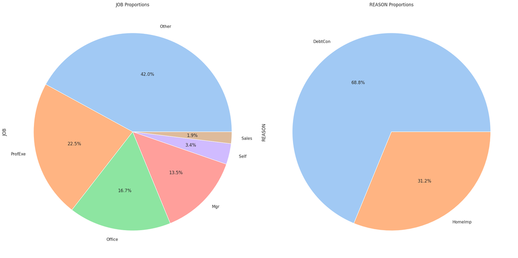

```python
# Set up the matplotlib figure
plt.figure(figsize=(20, 20))

# Loop through each categorical column and plot a pie chart
for i, column in enumerate(categorical_columns, 1):
    plt.subplot(1, len(categorical_columns), i)
    df[column].value_counts().plot.pie(autopct='%1.1f%%')
    plt.title(f'{column} Proportions')

plt.tight_layout()
plt.show()
```

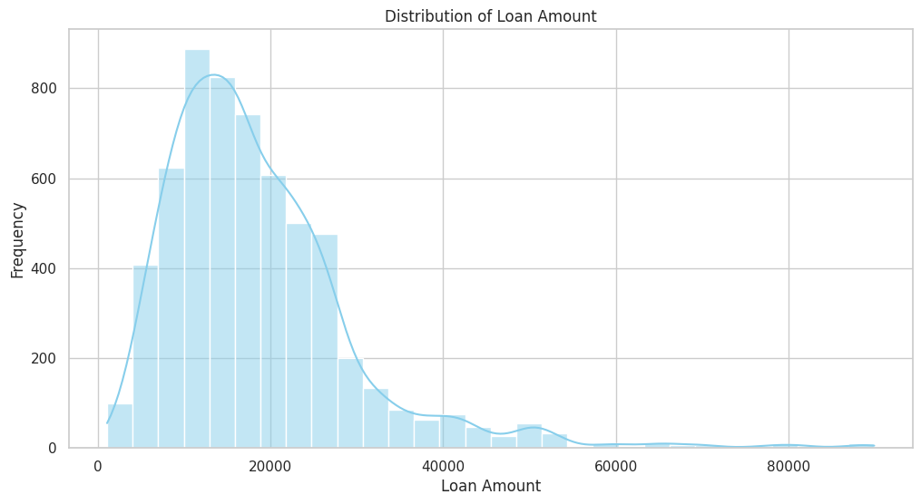

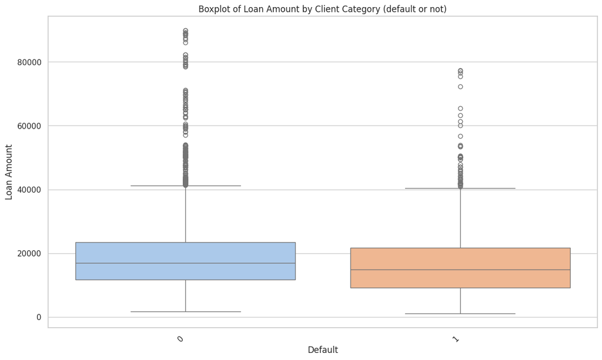

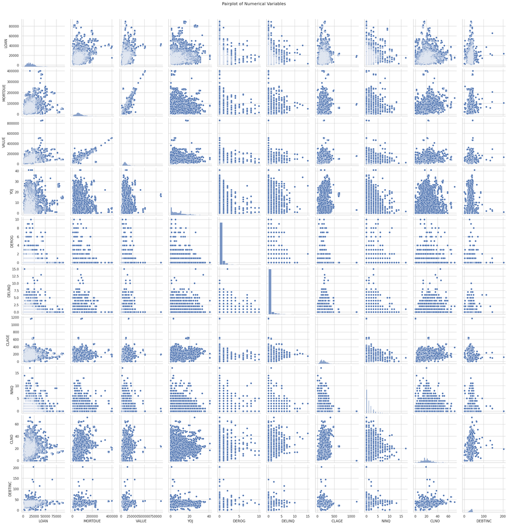

```python
# Set the style for seaborn plots
sns.set(style="whitegrid")

# Visualization 1: Distribution of 'LOAN'
plt.figure(figsize=(12, 6))
sns.histplot(df['LOAN'], bins=30, kde=True, color='skyblue')
plt.title('Distribution of Loan Amount')
plt.xlabel('Loan Amount')
plt.ylabel('Frequency')
plt.show()

# Visualization 2: Boxplot of 'LOAN' by 'BAD'
plt.figure(figsize=(14, 8))
sns.boxplot(x='BAD', y='LOAN', data=df, palette='pastel')
plt.title('Boxplot of Loan Amount by Client Category (default or not)')
plt.xlabel('Default')
plt.ylabel('Loan Amount')
plt.xticks(rotation=45, ha='right')
plt.show()

# Visualization 3: Pairplot for numerical variables
num_vars = ['LOAN', 'MORTDUE', 'VALUE', 'YOJ', 'DEROG', 'DELINQ', 'CLAGE',
            'NINQ', 'CLNO', 'DEBTINC']
sns.pairplot(df[num_vars], height=2.5)
plt.suptitle('Pairplot of Numerical Variables', y=1.02)
plt.show()
```

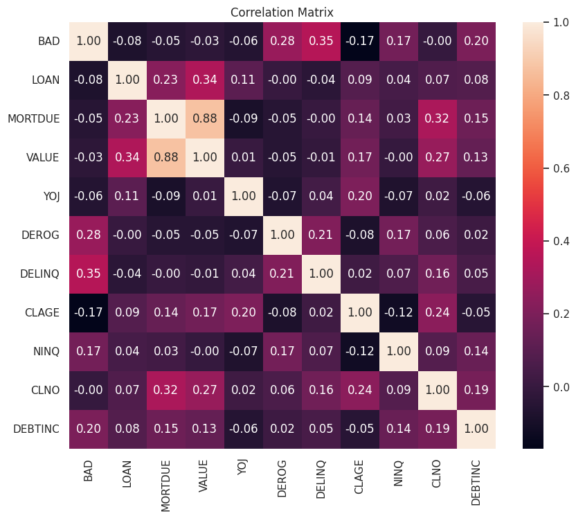

```python
# Compute the correlation matrix
correlation_matrix = df.corr()

# Plot the correlation matrix using seaborn
plt.figure(figsize=(10, 8))
sns.heatmap(correlation_matrix, annot=True, fmt=".2f", square=True)
plt.title('Correlation Matrix')
plt.show()
```

```python
df=df.replace('?',np.nan) #Replace missing values "?" by "NaN"

df=df.fillna(df.median().iloc[0] ) #Replace missing values by the median

df_ms=pd.get_dummies(df['REASON']) #On transforme toutes les variables non numériques en variables binaires
df=pd.concat([df,df_ms],axis=1)
df=df.drop(columns='REASON')

df_educ=pd.get_dummies(df['JOB'])
df=pd.concat([df,df_educ],axis=1)
df=df.drop(columns='JOB')

df
```

|  | BAD | LOAN | MORTDUE | VALUE | YOJ | DEROG | DELINQ | CLAGE | NINQ | CLNO | ... | 0.0 | DebtCon | HomeImp | 0.0 | Mgr | Office | Other | ProfExe | Sales | Self |
| --- | --- | --- | --- | --- | --- | --- | --- | --- | --- | --- | --- | --- | --- | --- | --- | --- | --- | --- | --- | --- | --- |
| 0 | 1 | 1100 | 25860.0 | 39025.0 | 10.5 | 0.0 | 0.0 | 94.366667 | 1.0 | 9.0 | ... | 0 | 0 | 1 | 0 | 0 | 0 | 1 | 0 | 0 | 0 |
| 1 | 1 | 1300 | 70053.0 | 68400.0 | 7.0 | 0.0 | 2.0 | 121.833333 | 0.0 | 14.0 | ... | 0 | 0 | 1 | 0 | 0 | 0 | 1 | 0 | 0 | 0 |
| 2 | 1 | 1500 | 13500.0 | 16700.0 | 4.0 | 0.0 | 0.0 | 149.466667 | 1.0 | 10.0 | ... | 0 | 0 | 1 | 0 | 0 | 0 | 1 | 0 | 0 | 0 |
| 3 | 1 | 1500 | 0.0 | 0.0 | 0.0 | 0.0 | 0.0 | 0.000000 | 0.0 | 0.0 | ... | 1 | 0 | 0 | 1 | 0 | 0 | 0 | 0 | 0 | 0 |
| 4 | 0 | 1700 | 97800.0 | 112000.0 | 3.0 | 0.0 | 0.0 | 93.333333 | 0.0 | 14.0 | ... | 0 | 0 | 1 | 0 | 0 | 1 | 0 | 0 | 0 | 0 |
| ... | ... | ... | ... | ... | ... | ... | ... | ... | ... | ... | ... | ... | ... | ... | ... | ... | ... | ... | ... | ... | ... |
| 5955 | 0 | 88900 | 57264.0 | 90185.0 | 16.0 | 0.0 | 0.0 | 221.808718 | 0.0 | 16.0 | ... | 0 | 1 | 0 | 0 | 0 | 0 | 1 | 0 | 0 | 0 |
| 5956 | 0 | 89000 | 54576.0 | 92937.0 | 16.0 | 0.0 | 0.0 | 208.692070 | 0.0 | 15.0 | ... | 0 | 1 | 0 | 0 | 0 | 0 | 1 | 0 | 0 | 0 |
| 5957 | 0 | 89200 | 54045.0 | 92924.0 | 15.0 | 0.0 | 0.0 | 212.279697 | 0.0 | 15.0 | ... | 0 | 1 | 0 | 0 | 0 | 0 | 1 | 0 | 0 | 0 |
| 5958 | 0 | 89800 | 50370.0 | 91861.0 | 14.0 | 0.0 | 0.0 | 213.892709 | 0.0 | 16.0 | ... | 0 | 1 | 0 | 0 | 0 | 0 | 1 | 0 | 0 | 0 |
| 5959 | 0 | 89900 | 48811.0 | 88934.0 | 15.0 | 0.0 | 0.0 | 219.601002 | 0.0 | 16.0 | ... | 0 | 1 | 0 | 0 | 0 | 0 | 1 | 0 | 0 | 0 |

5960 rows × 21 columns

```python
df.describe()
```

|  | BAD | LOAN | MORTDUE | VALUE | YOJ | DEROG | DELINQ | CLAGE | NINQ | CLNO | ... | 0.0 | DebtCon | HomeImp | 0.0 | Mgr | Office | Other | ProfExe | Sales | Self |
| --- | --- | --- | --- | --- | --- | --- | --- | --- | --- | --- | --- | --- | --- | --- | --- | --- | --- | --- | --- | --- | --- |
| count | 5960.000000 | 5960.000000 | 5960.000000 | 5960.000000 | 5960.000000 | 5960.000000 | 5960.000000 | 5960.000000 | 5960.000000 | 5960.000000 | ... | 5960.000000 | 5960.000000 | 5960.000000 | 5960.000000 | 5960.000000 | 5960.000000 | 5960.000000 | 5960.000000 | 5960.000000 | 5960.000000 |
| mean | 0.199497 | 18607.969799 | 67350.061611 | 99863.478698 | 8.151300 | 0.224329 | 0.405705 | 170.476340 | 1.084564 | 20.502852 | ... | 0.042282 | 0.659060 | 0.298658 | 0.046812 | 0.128691 | 0.159060 | 0.400671 | 0.214094 | 0.018289 | 0.032383 |
| std | 0.399656 | 11207.480417 | 47291.714068 | 58500.089789 | 7.661131 | 0.798458 | 1.079256 | 92.556818 | 1.686017 | 10.734746 | ... | 0.201248 | 0.474065 | 0.457708 | 0.211254 | 0.334886 | 0.365763 | 0.490076 | 0.410227 | 0.134004 | 0.177029 |
| min | 0.000000 | 1100.000000 | 0.000000 | 0.000000 | 0.000000 | 0.000000 | 0.000000 | 0.000000 | 0.000000 | 0.000000 | ... | 0.000000 | 0.000000 | 0.000000 | 0.000000 | 0.000000 | 0.000000 | 0.000000 | 0.000000 | 0.000000 | 0.000000 |
| 25% | 0.000000 | 11100.000000 | 38996.500000 | 65000.000000 | 2.000000 | 0.000000 | 0.000000 | 107.670203 | 0.000000 | 14.000000 | ... | 0.000000 | 0.000000 | 0.000000 | 0.000000 | 0.000000 | 0.000000 | 0.000000 | 0.000000 | 0.000000 | 0.000000 |
| 50% | 0.000000 | 16300.000000 | 61739.500000 | 88310.500000 | 6.000000 | 0.000000 | 0.000000 | 166.675508 | 0.000000 | 20.000000 | ... | 0.000000 | 1.000000 | 0.000000 | 0.000000 | 0.000000 | 0.000000 | 0.000000 | 0.000000 | 0.000000 | 0.000000 |
| 75% | 0.000000 | 23300.000000 | 88200.250000 | 119004.750000 | 12.000000 | 0.000000 | 0.000000 | 227.143058 | 2.000000 | 26.000000 | ... | 0.000000 | 1.000000 | 1.000000 | 0.000000 | 0.000000 | 0.000000 | 1.000000 | 0.000000 | 0.000000 | 0.000000 |
| max | 1.000000 | 89900.000000 | 399550.000000 | 855909.000000 | 41.000000 | 10.000000 | 15.000000 | 1168.233561 | 17.000000 | 71.000000 | ... | 1.000000 | 1.000000 | 1.000000 | 1.000000 | 1.000000 | 1.000000 | 1.000000 | 1.000000 | 1.000000 | 1.000000 |

8 rows × 21 columns

```python
# Display the first few rows of the DataFrame
print("First few rows of the data:")
print(df.head())

# Check the data types and missing values
print("\nData types and missing values:")
print(df.info())
```

```
First few rows of the data:
   BAD  LOAN  MORTDUE     VALUE   YOJ  DEROG  DELINQ       CLAGE  NINQ  CLNO  \
0    1  1100  25860.0   39025.0  10.5    0.0     0.0   94.366667   1.0   9.0
1    1  1300  70053.0   68400.0   7.0    0.0     2.0  121.833333   0.0  14.0
2    1  1500  13500.0   16700.0   4.0    0.0     0.0  149.466667   1.0  10.0
3    1  1500      0.0       0.0   0.0    0.0     0.0    0.000000   0.0   0.0
4    0  1700  97800.0  112000.0   3.0    0.0     0.0   93.333333   0.0  14.0

   ...  0.0  DebtCon  HomeImp  0.0  Mgr  Office  Other  ProfExe  Sales  Self
0  ...    0        0        1    0    0       0      1        0      0     0
1  ...    0        0        1    0    0       0      1        0      0     0
2  ...    0        0        1    0    0       0      1        0      0     0
3  ...    1        0        0    1    0       0      0        0      0     0
4  ...    0        0        1    0    0       1      0        0      0     0

[5 rows x 21 columns]

Data types and missing values:
<class 'pandas.core.frame.DataFrame'>
RangeIndex: 5960 entries, 0 to 5959
Data columns (total 21 columns):
 #   Column   Non-Null Count  Dtype
---  ------   --------------  -----
 0   BAD      5960 non-null   int64
 1   LOAN     5960 non-null   int64
 2   MORTDUE  5960 non-null   float64
 3   VALUE    5960 non-null   float64
 4   YOJ      5960 non-null   float64
 5   DEROG    5960 non-null   float64
 6   DELINQ   5960 non-null   float64
 7   CLAGE    5960 non-null   float64
 8   NINQ     5960 non-null   float64
 9   CLNO     5960 non-null   float64
 10  DEBTINC  5960 non-null   float64
 11  0.0      5960 non-null   uint8
 12  DebtCon  5960 non-null   uint8
 13  HomeImp  5960 non-null   uint8
 14  0.0      5960 non-null   uint8
 15  Mgr      5960 non-null   uint8
 16  Office   5960 non-null   uint8
 17  Other    5960 non-null   uint8
 18  ProfExe  5960 non-null   uint8
 19  Sales    5960 non-null   uint8
 20  Self     5960 non-null   uint8
dtypes: float64(9), int64(2), uint8(10)
memory usage: 570.5 KB
None
```

```python
df.drop(df.columns[11], axis=1, inplace = True)
df.info()
```

```
<class 'pandas.core.frame.DataFrame'>
RangeIndex: 5960 entries, 0 to 5959
Data columns (total 19 columns):
 #   Column   Non-Null Count  Dtype
---  ------   --------------  -----
 0   BAD      5960 non-null   int64
 1   LOAN     5960 non-null   int64
 2   MORTDUE  5960 non-null   float64
 3   VALUE    5960 non-null   float64
 4   YOJ      5960 non-null   float64
 5   DEROG    5960 non-null   float64
 6   DELINQ   5960 non-null   float64
 7   CLAGE    5960 non-null   float64
 8   NINQ     5960 non-null   float64
 9   CLNO     5960 non-null   float64
 10  DEBTINC  5960 non-null   float64
 11  DebtCon  5960 non-null   uint8
 12  HomeImp  5960 non-null   uint8
 13  Mgr      5960 non-null   uint8
 14  Office   5960 non-null   uint8
 15  Other    5960 non-null   uint8
 16  ProfExe  5960 non-null   uint8
 17  Sales    5960 non-null   uint8
 18  Self     5960 non-null   uint8
dtypes: float64(9), int64(2), uint8(8)
memory usage: 558.9 KB
```

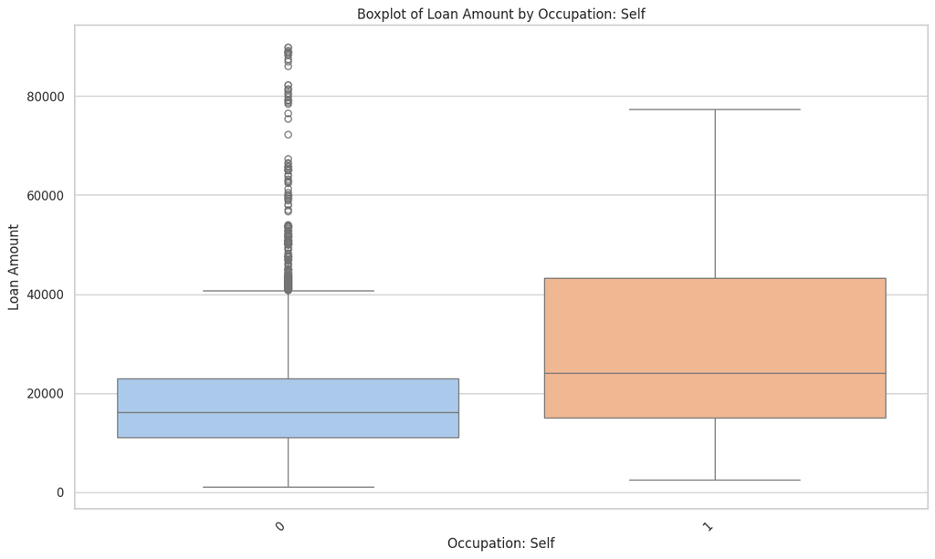

```python
# Set the style for seaborn plots
sns.set(style="whitegrid")


# Visualization 4: Boxplot of 'LOAN' by 'JOB'
plt.figure(figsize=(14, 8))
sns.boxplot(x='Self', y='LOAN', data=df, palette='pastel')
plt.title('Boxplot of Loan Amount by Occupation: Self')
plt.xlabel('Occupation: Self')
plt.ylabel('Loan Amount')
plt.xticks(rotation=45, ha='right')
plt.show()
```

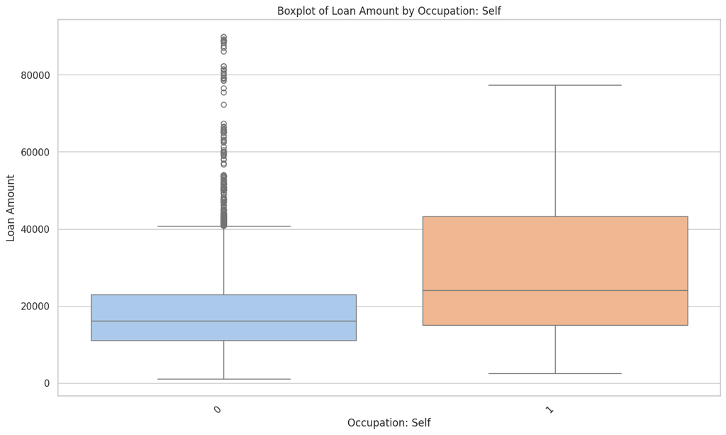

```python
# Set the style for seaborn plots
sns.set(style="whitegrid")


# Visualization 4: Boxplot of 'LOAN' by 'JOB'
plt.figure(figsize=(14, 8))
sns.boxplot(x='Self', y='LOAN', data=df, palette='pastel')
plt.title('Boxplot of Loan Amount by Occupation: Self')
plt.xlabel('Occupation: Self')
plt.ylabel('Loan Amount')
plt.xticks(rotation=45, ha='right')
plt.show()
```

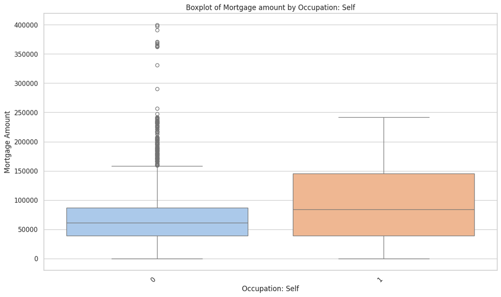

```python
# Set the style for seaborn plots
sns.set(style="whitegrid")


# Visualization 4: Boxplot of 'LOAN' by 'JOB'
plt.figure(figsize=(14, 8))
sns.boxplot(x='Self', y='MORTDUE', data=df, palette='pastel')
plt.title('Boxplot of Mortgage amount by Occupation: Self')
plt.xlabel('Occupation: Self')
plt.ylabel('Mortgage Amount')
plt.xticks(rotation=45, ha='right')
plt.show()
```

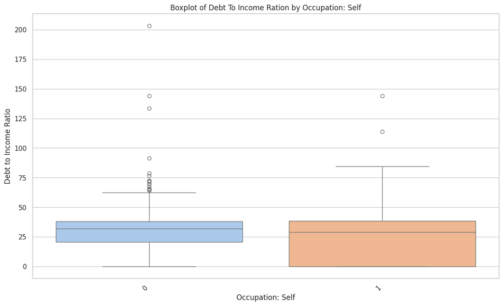

```python
# Set the style for seaborn plots
sns.set(style="whitegrid")


# Visualization 4: Boxplot of 'LOAN' by 'JOB'
plt.figure(figsize=(14, 8))
sns.boxplot(x='Self', y='DEBTINC', data=df, palette='pastel')
plt.title('Boxplot of Debt To Income Ration by Occupation: Self')
plt.xlabel('Occupation: Self')
plt.ylabel('Debt to Income Ratio')
plt.xticks(rotation=45, ha='right')
plt.show()
```

## General Description of the dataset

The DataFrame displays the first 5 rows of the dataset, for all 21 columns and a total of 5960 entries i.e., 5960 orders.

Furthermore, the dataset provides the amount of loan approved, as well as the amount due on the existing mortgage, the current value of the property, the reason of the loan request, the client's occupation, the number of derogatory reports, the age of the oldest credit line in months, the number of recent credit inquiries, the number of existing credit lines as well as the debt-to-income ration.

## Data Types and Missing Values

### Créer une base d'apprentissage et une base de test (70% apprentissage 30% test)

```python
from sklearn.model_selection import train_test_split #Donne train et test
train,test = train_test_split(df, test_size=0.3)

#train
#test
```

## II. Bias Computation

Make a function *disparate_impact(Y,S)* that takes two binary vectors, one corresponding to $\hat{Y}$ (or $Y$) ,the other to $S$ and calculates the disparate impact: $$ DI(\hat{Y},S)=\frac{P(\hat{Y}=1|S=0)}{P(\hat{Y}=1|S=1)} $$

- calculate the disparate impact of the train and test bases for $Y$ corresponding to $BAD$ and $S$ corresponding to *SELF*.

Using *scikit-learn* :

- Make a classifier to predict the class *BAD*.
- Predict the class *BAD* on the test basis (this will be our $\hat{Y}$)
- Calculate the classification rate and disparate impact of $\hat{Y}$ for $S$ corresponding to *SELF* on the test base.
- Try out several classifiers.
- Test at least 5 algorithms (including random forest and XGboost), looking for optimal parameters.
- Make comparative graphs of classification rate and disparate impact values.

Repeat the previous steps, removing the *SELF* column from the attributes used by the classifier.

Create a function to calculate the error ratio of the classifiers: $$ DI(\hat{Y},S)=\frac{P(Y=1|\hat{Y}=1,S=0)}{P(Y=1|\hat{Y}=1,S=1)} $$ Add a graph comparing error ratio values for classifiers

### 1)Compute the *disparate_impact(Y,S)* function that takes two binary variables $\hat{Y}$ (or $Y$) , and $S$ such that:

```python
def disparate_impact(Y,S):   #Fonction disparate_impact
    num=sum((Y==1)&(S==0))/sum((S==0))
    den=sum((Y==1)&(S==1))/sum((S==1))
    return num/den
```

### 2) calculate the disparate impact of the train and test bases for $Y$ corresponding to $BAD$ and $S$ corresponding to *SELF*.

```python
d_train_1=disparate_impact(train["BAD"],train["Self"])
print("the disparate impact for the train base corresponding to Bad and Self is",d_train_1)
```

```
the disparate impact for the train base corresponding to Bad and Self is 0.6995175418052368
```

```python
d_test_1=disparate_impact(test["BAD"],test["Self"])
print("the disparate impact for the test base corresponding to Bad and Self is",d_train_1)
```

```
the disparate impact for the test base corresponding to Bad and Self is 0.6995175418052368
```

### 4) Build a classifier to predict "BAD"

#### *Calculate classification rate and disparate impact of $\hat{Y}$ for $S$ corresponding to* SELF* on test basis

#### * Test at least 5 algorithms (including random forest and XGboost), looking for optimal parameters. Make comparative graphs of classification rate and disparate impact values.

```python
X_train=pd.DataFrame(train.drop(columns="BAD")) #On découpe train et test en des bases X et Y
Y_train=pd.DataFrame(train["BAD"])

X_test=pd.DataFrame(test.drop(columns="BAD"))
Y_test=pd.DataFrame(test["BAD"])
```

### Logistic Classifier

```python
 from sklearn.linear_model import LogisticRegression
lr=LogisticRegression(tol=0.1,max_iter= 300,solver='lbfgs')
X_train.columns = X_train.columns.astype(str)
lr.fit(X_train,np.ravel(Y_train.values))
```

```
LogisticRegression(max_iter=300, tol=0.1)
```

```python
X_test.columns = X_test.columns.astype(str)

pred_lr = lr.predict(X_test)
labels_lr=np.ravel(Y_test.values)
pred_df = pd.DataFrame({"BAD": test["BAD"], "SELF":test["Self"], "preds": pred_lr})
```

```python
def prediction(labels,pred):
    c=0 #Initialize count at 0
    lim = int(len(pred))
    for i in range(lim):
        if pred[i]!=labels[i]:
            c=c+1 #+1 to counter if prediction is different from label (for each value)
    score=100-float(c)/lim*100 #Compute Score
    return score

prediction(labels_lr,pred_lr)
```

```
84.39597315436242
```

##### We calculate the classification rate (Note: this is actually the output of the prediction function. Prediction is % of classification rate

```python
score_lr=lr.score(X_test,np.ravel(Y_test.values))
score_lr
```

```
0.8439597315436241
```

```python
d_test_lr=disparate_impact(pred_df["preds"],pred_df["SELF"])
print("the disparate impact of the logistic regression is",d_test_lr, "and the classification rate is",score_lr)
```

```
the disparate impact of the logistic regression is 0.41666666666666674 and the classification rate is 0.8439597315436241
```

### Random Forest Classifier

```python
from sklearn.ensemble import RandomForestClassifier
rf = RandomForestClassifier(n_estimators=100,max_depth=20,random_state=0)
rf.fit(X_train,np.ravel(Y_train.values))
```

```
RandomForestClassifier(max_depth=20, random_state=0)
```

```python
pred_rf = rf.predict(X_test)
labels_rf=np.ravel(Y_test.values)
pred_df = pd.DataFrame({"BAD": test["BAD"], "SELF":test["Self"], "preds": pred_rf})
prediction(labels_rf,pred_rf)
```

```
91.72259507829978
```

```python
score_rf=rf.score(X_test,np.ravel(Y_test.values))
score_rf
```

```
0.9172259507829977
```

```python
d_test_rf=disparate_impact(pred_df["preds"],pred_df["SELF"])
print("Random Forest's disparate impact is",d_test_rf, "and the classification rate is",score_rf)
```

```
Random Forest's disparate impact is 0.535453216374269 and the classification rate is 0.9172259507829977
```

### XGBoost classifier

```python
#!pip install xgboost
```

```python
from xgboost import XGBClassifier
XGB = XGBClassifier()
XGB.fit(X_train,np.ravel(Y_train.values))
```

```
XGBClassifier(base_score=None, booster=None, callbacks=None,
              colsample_bylevel=None, colsample_bynode=None,
              colsample_bytree=None, device=None, early_stopping_rounds=None,
              enable_categorical=False, eval_metric=None, feature_types=None,
              gamma=None, grow_policy=None, importance_type=None,
              interaction_constraints=None, learning_rate=None, max_bin=None,
              max_cat_threshold=None, max_cat_to_onehot=None,
              max_delta_step=None, max_depth=None, max_leaves=None,
              min_child_weight=None, missing=nan, monotone_constraints=None,
              multi_strategy=None, n_estimators=None, n_jobs=None,
              num_parallel_tree=None, random_state=None, ...)
```

```python
pred_XGB = XGB.predict(X_test)
labels_XGB=np.ravel(Y_test.values)
pred_df = pd.DataFrame({"BAD": test["BAD"], "SELF":test["Self"], "preds": pred_XGB})
prediction(labels_XGB,pred_XGB)
```

```
92.5055928411633
```

```python
score_XGB=XGB.score(X_test,np.ravel(Y_test.values))
score_XGB
```

```
0.9250559284116331
```

```python
d_test_XGB=disparate_impact(pred_df["preds"],pred_df["SELF"])
print("the disparate impact of XGBoost is",d_test_XGB, "and the classification rate is",score_XGB)
```

```
the disparate impact of XGBoost is 0.5594135802469136 and the classification rate is 0.9250559284116331
```

### Decision Tree Classifier

```python
from sklearn import tree
tr = tree.DecisionTreeClassifier()
tr.fit(X_train,np.ravel(Y_train.values))
```

```
DecisionTreeClassifier()
```

```python
pred_tr = tr.predict(X_test)
labels_tr=np.ravel(Y_test.values)
pred_df2 = pd.DataFrame({"BAD": test["BAD"], "SELF":test["Self"], "preds": pred_tr})
prediction(labels_tr,pred_tr)
```

```
87.13646532438479
```

```python
score_tr=tr.score(X_test,np.ravel(Y_test.values))
score_tr
```

```
0.8713646532438478
```

```python
d_test_tr=disparate_impact(pred_df2["preds"],pred_df2["SELF"])
print("the disparate impact of the decision tree is",d_test_tr, "and the classification rate is",score_tr)
```

```
the disparate impact of the decision tree is 0.6270424836601307 and the classification rate is 0.8713646532438478
```

### KNN Classifier

```python
from sklearn.neighbors import KNeighborsClassifier
knn = KNeighborsClassifier(n_neighbors=3)
knn.fit(X_train,np.ravel(Y_train.values))
```

```
KNeighborsClassifier(n_neighbors=3)
```

```python
pred_knn=knn.predict(X_test)
labels_knn=np.ravel(Y_test.values)
pred_df3 = pd.DataFrame({"BAD": test["BAD"], "SELF":test["Self"], "preds": pred_knn})
prediction(labels_knn,pred_knn)
```

```
82.15883668903803
```

```python
score_knn=knn.score(X_test,np.ravel(Y_test.values))
score_knn
```

```
0.8215883668903803
```

```python
d_test_knn=disparate_impact(pred_df3["preds"],pred_df3["SELF"])
print("the disparate impact of the k n nearest neighbors is",d_test_knn, "and the classification rate is",score_knn)
```

```
the disparate impact of the k n nearest neighbors is 0.7253086419753086 and the classification rate is 0.8215883668903803
```

### Gaussian NB Classifier

```python
from sklearn.naive_bayes import GaussianNB
clf = GaussianNB()
clf.fit(X_train, np.ravel(Y_train.values))
```

```
GaussianNB()
```

```python
pred_clf=clf.predict(X_test)
labels_clf=np.ravel(Y_test.values)
pred_df4 = pd.DataFrame({"BAD": test["BAD"], "SELF":test["Self"], "preds": pred_clf})
prediction(labels_clf,pred_clf)
```

```
88.19910514541387
```

```python
score_clf=clf.score(X_test,np.ravel(Y_test.values))
score_clf
```

```
0.8819910514541387
```

```python
d_test_clf=disparate_impact(pred_df4["preds"],pred_df4["SELF"])
print("the disparate impact is the Gaussian method is",d_test_clf, " and the classification rate is",score_clf)
```

```
the disparate impact is the Gaussian method is 0.559640522875817  and the classification rate is 0.8819910514541387
```

### Comparison

```python
print("the disparate impact using the gaussian method is",d_test_clf,'and its corresponding classification rate is', score_clf)
print("the disparate impact using the k n nearest neighbor method is",d_test_knn,'and its corresponding classification rate is', score_knn)
print("the disparate impact using the decision tree method is",d_test_tr,'and its corresponding classification rate is', score_tr)
print("the disparate impact using the logistic regression method is",d_test_lr,'and its corresponding classification rate is', score_lr)
print("the disparate impact using the random forest method is",d_test_rf,'and its corresponding classification rate is', score_rf)
print("the disparate impact using the XGBoost method is",d_test_XGB,'and its corresponding classification rate is', score_XGB)
```

```
the disparate impact using the gaussian method is 0.559640522875817 and its corresponding classification rate is 0.8819910514541387
the disparate impact using the k n nearest neighbor method is 0.7253086419753086 and its corresponding classification rate is 0.8215883668903803
the disparate impact using the decision tree method is 0.6270424836601307 and its corresponding classification rate is 0.8713646532438478
the disparate impact using the logistic regression method is 0.41666666666666674 and its corresponding classification rate is 0.8439597315436241
the disparate impact using the random forest method is 0.535453216374269 and its corresponding classification rate is 0.9172259507829977
the disparate impact using the XGBoost method is 0.5594135802469136 and its corresponding classification rate is 0.9250559284116331
```

### We optimize Logistic Classifier

```python
from sklearn.model_selection import GridSearchCV
lr=LogisticRegression(max_iter=300)
parameters = {
    "solver":['newton-cg','lbfgs','liblinear','sag','saga'],
    "multi_class":['auto','ovr','multinomial']}
lr_opti = GridSearchCV(lr, parameters, cv=5, scoring='accuracy')
lr_opti.fit(X_train,np.ravel(Y_train.values))

score_opti_lr=lr_opti.best_score_
pred_opti_lr=lr_opti.predict(X_test)
di_opti_lr=disparate_impact(pred_opti_lr,test["Self"])
print("We observe that the best score for the logistic regression method is:", score_opti_lr)
print("Optimized parameters for logistic regression are:",lr_opti.best_params_)
print('the old score was', score_lr)
print('the new disparate impact is',di_opti_lr)
```

[output not shown]

[output cut: 151 more lines]

[output not shown]

```
We observe that the best score for the logistic regression method is: 0.8784784388058415
Optimized parameters for logistic regression are: {'multi_class': 'auto', 'solver': 'newton-cg'}
the old score was 0.8439597315436241
the new disparate impact is 0.4904513888888889
```

### We optimize Random Forest Classifier

```python
from sklearn.model_selection import GridSearchCV
rf = RandomForestClassifier(n_estimators=100,random_state = 0)
parameters = {
    "max_depth":range(1,15),
    "min_samples_leaf":range(1,20)}
rf_opti = GridSearchCV(rf,parameters,cv=5,scoring='accuracy')
rf_opti.fit(X_train.values,np.ravel(Y_train.values))

score_opti_rf=rf_opti.best_score_
pred_opti_rf=rf_opti.predict(X_test)
di_opti_rf=disparate_impact(pred_opti_rf,test["Self"])
print("We observe that the best score for the Random Forest method is:", score_opti_rf)
print("Optimized parameters for the Random Forest method are:",rf_opti.best_params_)
print('the old score was', score_rf)
print('the new disparate impact is',di_opti_rf)
```

```
We observe that the best score for the Random Forest method is: 0.9038843176955442
Optimized parameters for the Random Forest method are: {'max_depth': 14, 'min_samples_leaf': 1}
the old score was 0.9172259507829977
the new disparate impact is 0.5171783625730995
```

```python
rf_opti.best_params_
```

```
{'max_depth': 14, 'min_samples_leaf': 1}
```

### We optimize XGBoost

```python
from sklearn.model_selection import GridSearchCV
XGB = XGBClassifier()
parameters = {
    "max_depth":range(3,10)}
XGB_opti = GridSearchCV(XGB,parameters,cv=5, scoring='accuracy')
XGB_opti.fit(X_train,np.ravel(Y_train.values))

score_opti_XGB=XGB_opti.best_score_
pred_opti_XGB=XGB_opti.predict(X_test)
di_opti_XGB=disparate_impact(pred_opti_XGB,test["Self"])


print("We observe that the best score for the XGBoost method is:", score_opti_XGB)
print("Optimized parameters for XGBoost method is:",XGB_opti.best_params_)
print("The old score was",score_XGB)
print("the new disparate impact is",di_opti_XGB)
```

```
We observe that the best score for the XGBoost method is: 0.9153893651545829
Optimized parameters for XGBoost method is: {'max_depth': 5}
The old score was 0.9250559284116331
the new disparate impact is 0.5497685185185185
```

```python
XGB_opti.best_params_
```

```
{'max_depth': 5}
```

### We optimize the Gaussian NB Classifier

```python
from sklearn.model_selection import GridSearchCV
clf = GaussianNB()
parameters = {
    "var_smoothing":np.arange(1e-9,1,0.1)}
clf_opti = GridSearchCV(clf,parameters,cv=5, scoring='accuracy')
clf_opti.fit(X_train,np.ravel(Y_train.values))

score_opti_clf=clf_opti.best_score_
pred_opti_clf=clf_opti.predict(X_test)
di_opti_clf=disparate_impact(pred_opti_clf,test["Self"])

print("We observe that the best score for the Gaussian method is:", clf_opti.best_score_)
print("Optimized parameters for the Gaussian method are:",clf_opti.best_params_)
print("The old score was",score_clf)
print("The new disparate impact is",di_opti_clf)
```

```
We observe that the best score for the Gaussian method is: 0.8734456267321471
Optimized parameters for the Gaussian method are: {'var_smoothing': 1e-09}
The old score was 0.8819910514541387
The new disparate impact is 0.559640522875817
```

### We optimize KNN

```python
from sklearn.model_selection import GridSearchCV
knn = KNeighborsClassifier()
parameters = {
    "n_neighbors":range(1,15),
    "weights":["distance", "uniform"]}
knn_opti = GridSearchCV(knn,parameters,cv=5, scoring='accuracy')
knn_opti.fit(X_train,np.ravel(Y_train.values))

score_opti_knn=knn_opti.best_score_
pred_opti_knn=knn_opti.predict(X_test)
di_opti_knn=disparate_impact(pred_opti_knn,test["Self"])

print("We observe that the best score for the k n nearest neighbors method is:", knn_opti.best_score_)
print("Optimized parameters for k n nearest neighbor method:",knn_opti.best_params_)
print("The old score was",score_knn)
print("The new disparate impact is",di_opti_knn)
```

```
We observe that the best score for the k n nearest neighbors method is: 0.8300564338948003
Optimized parameters for k n nearest neighbor method: {'n_neighbors': 2, 'weights': 'uniform'}
The old score was 0.8215883668903803
The new disparate impact is 0.5902777777777778
```

### We optimize Decision Tree Classifier

```python
from sklearn.model_selection import GridSearchCV
tr=tree.DecisionTreeClassifier()
parameters = {
    "max_depth":range(1,10),
    "min_samples_leaf":range(1,10)}
tr_opti = GridSearchCV(tr, parameters, cv=5, scoring='accuracy')
tr_opti.fit(X_train, np.ravel(Y_train.values))

score_opti_tr=tr_opti.best_score_
pred_opti_tr=tr_opti.predict(X_test)
di_opti_tr=disparate_impact(pred_opti_tr,test["Self"])
print("We observe that the best score for the decision tree method is:", score_opti_tr)
print("Optimized parameters for the decision tree method:",tr_opti.best_params_)
print('the old score was', score_tr)
print('the new disparate impact is',di_opti_tr)
```

```
We observe that the best score for the decision tree method is: 0.8777581527592296
Optimized parameters for the decision tree method: {'max_depth': 3, 'min_samples_leaf': 1}
the old score was 0.8713646532438478
the new disparate impact is 0.5729166666666667
```

### We compare the results

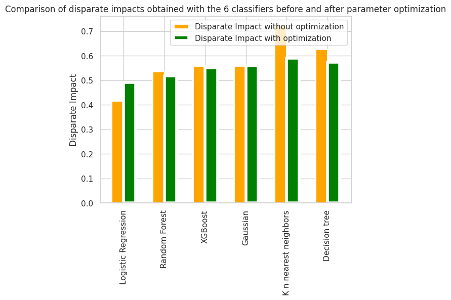

```python
di=[d_test_lr,d_test_rf,d_test_XGB,d_test_clf,d_test_knn,d_test_tr]
di_opti=[di_opti_lr,di_opti_rf,di_opti_XGB,di_opti_clf,di_opti_knn,di_opti_tr]
classifiers=['Logistic Regression','Random Forest','XGBoost','Gaussian','K n nearest neighbors','Decision tree']

x = np.arange(6)
barWidth=0.3

sansopti=plt.bar(x, di,width = barWidth, color = 'orange', linewidth = 2)
avecopti=plt.bar([i + barWidth for i in x], di_opti,width = barWidth, color = 'green', linewidth = 4)
plt.xticks([i + barWidth / 2 for i in x], classifiers, rotation='vertical')

plt.ylabel('Disparate Impact')
plt.title("Comparison of disparate impacts obtained with the 6 classifiers before and after parameter optimization")

plt.legend([sansopti, avecopti],['Disparate Impact without optimization', 'Disparate Impact with optimization'])
plt.show()
```

[figure not shown]

```python
scores=[score_lr,score_rf,score_XGB,score_clf,score_knn,score_tr]
scores_opti=[score_opti_lr,score_opti_rf,score_opti_XGB,score_opti_clf,score_opti_knn,score_opti_tr]
classifiers=['Logistic Regression','Random Forest','XGBoost','Gaussian','K n nearest neighbors','Decision tree']

x = np.arange(6)
barWidth=0.3

sansopti=plt.bar(x, scores,width = barWidth, color = 'orange', linewidth = 2)
avecopti=plt.bar([i + barWidth for i in x], scores_opti,width = barWidth, color ='green', linewidth = 4)
plt.xticks([i + barWidth / 2 for i in x], classifiers, rotation='vertical')

plt.ylabel('Score')
plt.title("Comparison of scores obtained with the 6 classifiers before and after parameter optimization")

plt.legend([sansopti, avecopti],['Scores without optimization', 'Scores with optimization'])
plt.show()
```

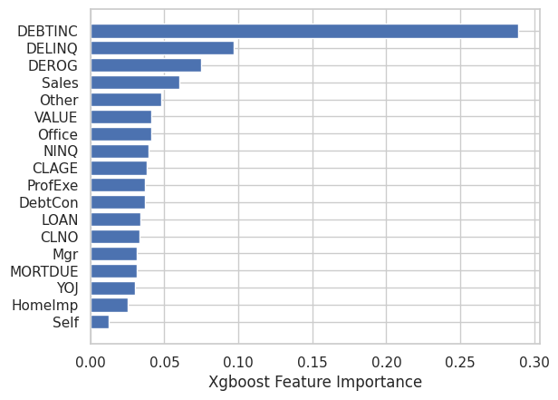

```python
# plot feature importance of XGBoost
XGB = XGBClassifier(max_depth=5)
XGB.fit(X_train,np.ravel(Y_train.values))
sorted_idx = XGB.feature_importances_.argsort()
plt.barh(X_train.columns[sorted_idx], XGB.feature_importances_[sorted_idx])
plt.xlabel("Xgboost Feature Importance")
```

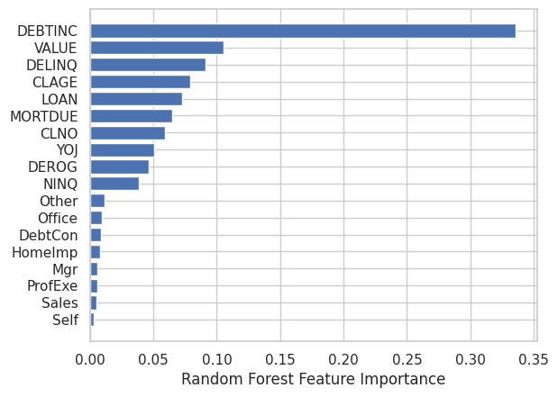

```python
# plot feature importance of Random Forest

rf = RandomForestClassifier(n_estimators=100,max_depth=14,random_state=0, min_samples_leaf=1)
rf.fit(X_train,np.ravel(Y_train.values))
sorted_idx = rf.feature_importances_.argsort()
plt.barh(X_train.columns[sorted_idx], rf.feature_importances_[sorted_idx])
plt.xlabel("Random Forest Feature Importance")
```

### We remove the Self column to compare results

```python
X_train_2=X_train.drop(columns = 'Self')
X_test_2=X_test.drop(columns = 'Self')
```

### Logistic Classifier

```python
lr=LogisticRegression(tol=0.1,max_iter= 300,solver='lbfgs')
lr.fit(X_train_2,np.ravel(Y_train.values))
```

```
LogisticRegression(max_iter=300, tol=0.1)
```

```python
pred_lr = lr.predict(X_test_2) #Prediction classe income
labels_lr=np.ravel(Y_test.values)
pred_df = pd.DataFrame({"BAD": test["BAD"], "SELF":test["Self"], "preds": pred_lr})
prediction(labels_lr,pred_lr)
```

```
84.39597315436242
```

```python
score_lr_2=lr.score(X_test_2,np.ravel(Y_test.values)) #Taux de classification
score_lr_2
```

```
0.8439597315436241
```

```python
d_test_lr_2=disparate_impact(pred_df["preds"],pred_df["SELF"]) #Disparate impact
print("the disparate impact of logistic regression is",d_test_lr_2, "and the classification rate is",score_lr_2)
```

```
the disparate impact of logistic regression is 0.41666666666666674 and the classification rate is 0.8439597315436241
```

### Random Forest Classifier

```python
rf = RandomForestClassifier(n_estimators=100,random_state = 0)
rf.fit(X_train_2,np.ravel(Y_train.values))
```

```
RandomForestClassifier(random_state=0)
```

```python
pred_rf = rf.predict(X_test_2)
labels_rf=np.ravel(Y_test.values)
pred_df = pd.DataFrame({"BAD": test["BAD"], "SELF":test["Self"], "preds": pred_rf})
prediction(labels_rf,pred_rf)
```

```
92.00223713646533
```

```python
score_rf_2=rf.score(X_test_2,np.ravel(Y_test.values))
score_rf_2
```

```
0.9200223713646533
```

```python
d_test_rf_2=disparate_impact(pred_df["preds"],pred_df["SELF"])
print("the disparate impact of Random Forest is",d_test_rf_2, "and the classification rate is",score_rf_2)
```

```
the disparate impact of Random Forest is 0.5767746913580247 and the classification rate is 0.9200223713646533
```

### XGBoost classifier

```python
XGB = XGBClassifier()
XGB.fit(X_train_2,np.ravel(Y_train.values))
```

```
XGBClassifier(base_score=None, booster=None, callbacks=None,
              colsample_bylevel=None, colsample_bynode=None,
              colsample_bytree=None, device=None, early_stopping_rounds=None,
              enable_categorical=False, eval_metric=None, feature_types=None,
              gamma=None, grow_policy=None, importance_type=None,
              interaction_constraints=None, learning_rate=None, max_bin=None,
              max_cat_threshold=None, max_cat_to_onehot=None,
              max_delta_step=None, max_depth=None, max_leaves=None,
              min_child_weight=None, missing=nan, monotone_constraints=None,
              multi_strategy=None, n_estimators=None, n_jobs=None,
              num_parallel_tree=None, random_state=None, ...)
```

```python
pred_XGB = XGB.predict(X_test_2)
labels_XGB=np.ravel(Y_test.values)
pred_df = pd.DataFrame({"BAD": test["BAD"], "SELF":test["Self"], "preds": pred_XGB})
prediction(labels_XGB,pred_XGB)
```

```
92.11409395973155
```

```python
score_XGB_2=XGB.score(X_test_2,np.ravel(Y_test.values))
score_XGB_2
```

```
0.9211409395973155
```

```python
d_test_XGB_2=disparate_impact(pred_df["preds"],pred_df["SELF"])
print("the disparate impact of XGBoost is",d_test_XGB_2, "and the classification rate is",score_XGB_2)
```

```
the disparate impact of XGBoost is 0.5497685185185185 and the classification rate is 0.9211409395973155
```

### Decision Tree Classifier

```python
tr = tree.DecisionTreeClassifier()
tr.fit(X_train_2,np.ravel(Y_train))
```

```
DecisionTreeClassifier()
```

```python
pred_tr = tr.predict(X_test_2)
labels_tr=np.ravel(Y_test.values)
pred_df2 = pd.DataFrame({"BAD": test["BAD"], "SELF":test["Self"], "preds": pred_tr})
prediction(labels_tr,pred_tr)
```

```
87.36017897091723
```

```python
score_tr_2=tr.score(X_test_2,np.ravel(Y_test.values))
d_test_tr_2=disparate_impact(pred_df2["preds"],pred_df2["SELF"])
print("the disparate impact of the decision tree is",d_test_tr_2, " and the classification rate is",score_tr_2)
```

```
the disparate impact of the decision tree is 0.613425925925926  and the classification rate is 0.8736017897091722
```

### KNN Classifier

```python
knn = KNeighborsClassifier(n_neighbors=3)
knn.fit(X_train_2,np.ravel(Y_train))
```

```
KNeighborsClassifier(n_neighbors=3)
```

```python
pred_knn=knn.predict(X_test_2)
labels_knn=np.ravel(Y_test.values)
pred_df3 = pd.DataFrame({"BAD": test["BAD"], "SELF":test["Self"], "preds": pred_knn})
prediction(labels_knn,pred_knn)
```

```
82.15883668903803
```

```python
score_knn_2=knn.score(X_test_2,np.ravel(Y_test))
d_test_knn_2=disparate_impact(pred_df3["preds"],pred_df3["SELF"])
print("the disparate impact of the k n nearest neighbors is",d_test_knn_2, " and the classification rate is",score_knn_2)
```

```
the disparate impact of the k n nearest neighbors is 0.7253086419753086  and the classification rate is 0.8215883668903803
```

### Gaussian NB Classifier

```python
clf = GaussianNB()
clf.fit(X_train_2, np.ravel(Y_train.values))
```

```
GaussianNB()
```

```python
pred_clf=clf.predict(X_test_2)
labels_clf=np.ravel(Y_test.values)
pred_df4 = pd.DataFrame({"BAD": test["BAD"], "SELF":test["Self"], "preds": pred_clf})
prediction(labels_clf,pred_clf)
```

```
88.25503355704699
```

```python
score_clf_2=clf.score(X_test_2,np.ravel(Y_test.values))
d_test_clf_2=disparate_impact(pred_df4["preds"],pred_df4["SELF"])
print("the disparate impact of the Gaussian method is",d_test_clf_2, " and the classification rate is",score_clf_2)
```

```
the disparate impact of the Gaussian method is 0.5616830065359477  and the classification rate is 0.8825503355704698
```